```python
import numpy as np
import matplotlib.pyplot as plt
from sympy import isprime
from random import uniform
```

# Different ways of calculating pi

While most of us first learned of pi as the circumfrence of a circle to its diameter, that's not the only way to find this constant. This notebook takes a look at some different ways of calculating pi and compares their usefullness, meassured in their convergence rate.

### Calculating pi from random floats (monte carlo method)

- Generate a list of sets of two random float numbers in the range [-1, 1], so they make up a square of sidelength two.
- Within this square you can find the unit circle with radius 1

\begin{equation} \begin{split} \text{We know the area of a circle is given by: } A = \pi r^2 \end{split} \end{equation}

- As the unit circle has a radius of one, we know it must have an area of π and the square must have an area of 2 * 2 = 4
- Using the formula below

\begin{equation} \begin{split} \frac{\text{dots within circle}}{\text{total dots}} = \frac{\text{area of circle}}{\text{area of square}} \implies \frac{\text{dots within circle} \cdot \text{area of square}}{\text{total dots}} = \text{area of circle} \end{split} \end{equation}\begin{equation} \begin{split} \frac{\text{area of circle}}{\text{area of square}} = \frac{\pi r^2}{4r^2} = \frac{\pi}{4} \end{split} \end{equation}

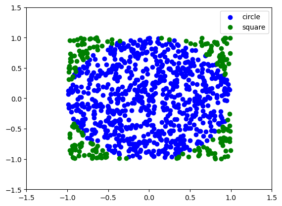

```
π ≈  3.176
```

```python
N = 1000

x_s = []
x_c = []
y_s = []
y_c = []

for i in range(N):
    a = uniform(-1,1)
    b = uniform(-1,1)

    #Checks if the absolute value (length) of the vector is larger than one. If so it's outside the circle
    if (a**2 + b**2 ) > 1:
        x_s.append(a)
        y_s.append(b)
    else:
        x_c.append(a)
        y_c.append(b)


plt.xlim(-1.5,1.5)
plt.ylim(-1.5,1.5)

plt.scatter(x_c,y_c, marker="o", color="blue", label="circle")
plt.scatter(x_s,y_s, marker="o", color="green", label="square")
plt.legend()
plt.show()

print("π ≈ ", (len(x_c)) / (len(x_s) + len(x_c)) * 4)
```

### Leibniz series for calculating pi

This leibniz series is a great way to calculate pi.  
\begin{equation} \frac{\pi}{4}=\sum_{i=0}^N \frac{ (-1)^i }{2i+1} \end{equation}

```python
N = 1000

sum = 0
for i in range(0,N):
    sum += ( (-1)**i ) / ( 2*i + 1)
print(sum*4)
```

```
3.140592653839794
```

Now we're getting into the more advanced methods of calculating pi

### Chudnovsky algorithm

The chudnovsky algorithm was first developed by the Cudnovsky brothers in the 1980's and used to break multiple world records. \begin{equation} \pi = \frac{426880 \sqrt{10005}}{\sum_{k=0}^{\infty}\frac{(6k)!(545140134 \cdot k + 13591409)}{(3k)!(k!)^{3}(-262537412640768000)^{k}}} \end{equation} As you can see from the below computation, this algorithm seems to converge quicker than python has the floating point accuracy to represent. In fact, After only two iterations, our float representation of pi is equal to numpy's pi constant. For more information on this I would suggest looking up implementations of chudnovsky.

```python
N = 2

c = 426880 * np.sqrt(10005)
m = 0

for i in range(0, N):
    m += ((np.math.factorial(6*i)) * (545140134*i + 13591409)) / ((np.math.factorial(3*i))*(np.math.factorial(i)**3)*(-262537412640768000)**i)

print(c/m)
print(abs(np.pi-(c/m)))

# pi 3.14159265358979323846264
```

```
3.141592653589793
0.0
```

# Convergence rate of these methods for calculating pi

- While these are indeed fun ways of calculating pi, some methods are more usefull compared to others
- This comparison shows you how quickly these methods converge on pi

```python
def piCircle(n):
    x_s = []
    x_c = []
    y_s = []
    y_c = []
    for i in range(n):
        a = uniform(-1,1)
        b = uniform(-1,1)

        #Checks if the absolute value (length) of the vector is larger than one. If so it's outside the circle
        if (a**2 + b**2 ) > 1:
            x_s.append(a)
            y_s.append(b)
        else:
            x_c.append(a)
            y_c.append(b)

    return (len(x_c)) / (len(x_s) + len(x_c)) * 4
```

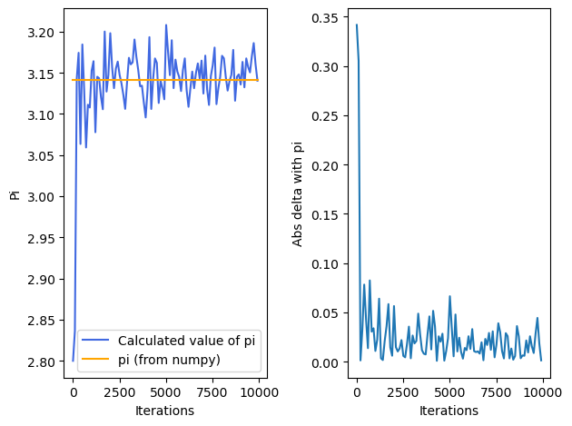

```
Estimate of pi:  3.1428
Delta with real value of pi (abs value):  0.00133029233853188
```

```python
piList = []
start = 10
stepsize = 100
N = 10000

x = np.arange(start, N, stepsize)

for i in range(start, N, stepsize):
    piList.append(piCircle(i))

piConst = np.ones(len(x))
piConst = piConst * np.pi

plt.subplot(1,2,1)
plt.plot(x, piList, color="royalblue", label="Calculated value of pi")
plt.plot(x, piConst, color="orange", label="pi (from numpy)")

plt.xlabel("Iterations")
plt.ylabel("Pi")

plt.legend()

plt.subplot(1,2,2)
piDelta = []
for i in piList:
    piDelta.append(abs(i - np.pi))
plt.plot(x, piDelta)

plt.xlabel("Iterations")
plt.ylabel("Abs delta with pi")

plt.tight_layout()
plt.show()

print("Estimate of pi: ", piCircle(N))
print("Delta with real value of pi (abs value): ", piDelta[-1])
```

As you can see the above plots shows that the random float method takes quite long to converge. In fact it's actually quite hard to say if it converges at all just from the plots alone. Below are the same plots, but for the leibniz series for pi

```python
def leibnizPi(n):
    sum = 0
    for i in range(n):
        if (i%2 == 0):
            sum += 1/(2*i + 1)
        else:
            sum += (-1)/(2*i+1)
    return sum*4
```

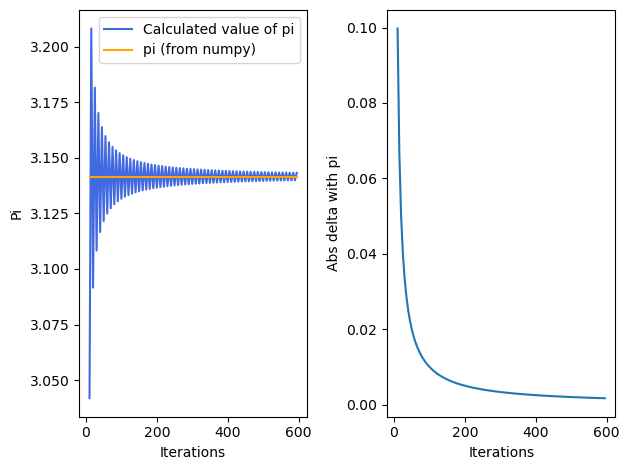

```
Estimate of pi:  3.139925988080531
Delta with real value of pi (abs value):  0.00168067108208092
```

```python
piList = []
start = 10
stepsize = 5
N = 600

x = np.arange(start, N, stepsize)

for i in range(start, N, stepsize):
    piList.append(leibnizPi(i))

piConst = np.ones(len(x))
piConst = piConst * np.pi

plt.subplot(1,2,1)
plt.plot(x, piList, color="royalblue", label="Calculated value of pi")
plt.plot(x, piConst, color="orange", label="pi (from numpy)")

plt.xlabel("Iterations")
plt.ylabel("Pi")

plt.legend()

plt.subplot(1,2,2)
piDelta = []
for i in piList:
    piDelta.append(abs(i - np.pi))
plt.plot(x, piDelta)

plt.xlabel("Iterations")
plt.ylabel("Abs delta with pi")

plt.tight_layout()
plt.show()

print("Estimate of pi: ", leibnizPi(N))
print("Delta with real value of pi (abs value): ", piDelta[-1])
```

Now we're talking convergence! Here we see a well behaved function that seems to converge at the first glance. Comparing these two functions we see the problem with the first random number pi function... its randomness! While it will absolutely give you pi given an infinite set of random numbers, calculating in infinite set of random numbers would take a bit too much computing power for this notebook. So while this is a really fun way to calculate pi, we can see that it's a very inefficient way to do so unfortunately.